# Exploratory Data Analysis on YouTube data.

# Domain: Social media

# ____________________________________________________________

# 1. Import required libraries and read the provided dataset (youtube_dislike_dataset.csv) and retrieve top 5 and bottom 5 records.

```python
# code imports the pandas library
import pandas as pd
import numpy as np
import matplotlib.pyplot as plt
import seaborn as sns
```

```python
# Read the Dataset
data = pd.read_csv('youtube_dislike_dataset.csv')
```

```python
# Display top 5 records
data.head(5)
```

|  | video_id | title | channel_id | channel_title | published_at | view_count | likes | dislikes | comment_count | tags | description | comments |
| --- | --- | --- | --- | --- | --- | --- | --- | --- | --- | --- | --- | --- |
| 0 | --0bCF-iK2E | Jadon Sancho Magical Skills & Goals | UC6UL29enLNe4mqwTfAyeNuw | Bundesliga | 2021-07-01 10:00:00 | 1048888 | 19515 | 226 | 1319 | football soccer ftbol alemn Bundesliga season ... | Enjoy the best skills and goals from Jadon San... | Respect to Dortmund fans,must be sad losing hi... |
| 1 | --14w5SOEUs | Migos - Avalanche (Official Video) | UCGIelM2Dj3zza3xyV3pL3WQ | MigosVEVO | 2021-06-10 16:00:00 | 15352638 | 359277 | 7479 | 18729 | Migos Avalanche Quality Control Music/Motown R... | Watch the the official video for Migos - "Aval... | Migos just makes me want to live my live to th... |
| 2 | --40TEbZ9Is | Supporting Actress in a Comedy: 73rd Emmys | UClBKH8yZRcM4AsRjDVEdjMg | Television Academy | 2021-09-20 01:03:32 | 925281 | 11212 | 401 | 831 |  | Hannah Waddingham wins the Emmy for Supporting... | Hannah's energy bursts through any screen. Wel... |
| 3 | --4tfbSyYDE | JO1'YOUNG (JO1 ver.)' PERFORMANCE VIDEO | UCsmXiDP8S40uBeJYxvyulmA | JO1 | 2021-03-03 10:00:17 | 2641597 | 39131 | 441 | 3745 | PRODUCE101JAPAN JO1 TheSTAR STA... | JO1'YOUNG (JO1 ver.)' PERFORMANCE VIDEO\n\n---... | youngVer>< REN is really PERFECT. It's not ju... |
| 4 | --DKkzWVh-E | Why Retaining Walls Collapse | UCMOqf8ab-42UUQIdVoKwjlQ | Practical Engineering | 2021-12-07 13:00:00 | 715724 | 32887 | 367 | 1067 | retaining wall New Jersey highway Direct Conne... | One of the most important (and innocuous) part... | Keep up with all my projects here: https://pr... |

```python
# Display top 5 records
top_5_records = data.head(5)
print("Top 5 records:")
print(top_5_records)
```

```
Top 5 records:
      video_id                                       title  \
0  --0bCF-iK2E        Jadon Sancho  Magical Skills & Goals
1  --14w5SOEUs          Migos - Avalanche (Official Video)
2  --40TEbZ9Is  Supporting Actress in a Comedy: 73rd Emmys
3  --4tfbSyYDE     JO1'YOUNG (JO1 ver.)' PERFORMANCE VIDEO
4  --DKkzWVh-E                Why Retaining Walls Collapse

                 channel_id          channel_title         published_at  \
0  UC6UL29enLNe4mqwTfAyeNuw             Bundesliga  2021-07-01 10:00:00
1  UCGIelM2Dj3zza3xyV3pL3WQ              MigosVEVO  2021-06-10 16:00:00
2  UClBKH8yZRcM4AsRjDVEdjMg     Television Academy  2021-09-20 01:03:32
3  UCsmXiDP8S40uBeJYxvyulmA                    JO1  2021-03-03 10:00:17
4  UCMOqf8ab-42UUQIdVoKwjlQ  Practical Engineering  2021-12-07 13:00:00

   view_count   likes  dislikes  comment_count  \
0     1048888   19515       226           1319
1    15352638  359277      7479          18729
2      925281   11212       401            831
3     2641597   39131       441           3745
4      715724   32887       367           1067

                                                tags  \
0  football soccer ftbol alemn Bundesliga season ...
1  Migos Avalanche Quality Control Music/Motown R...
2
3  PRODUCE101JAPAN              JO1   TheSTAR STA...
4  retaining wall New Jersey highway Direct Conne...

                                         description  \
0  Enjoy the best skills and goals from Jadon San...
1  Watch the the official video for Migos - "Aval...
2  Hannah Waddingham wins the Emmy for Supporting...
3  JO1'YOUNG (JO1 ver.)' PERFORMANCE VIDEO\n\n---...
4  One of the most important (and innocuous) part...

                                            comments
0  Respect to Dortmund fans,must be sad losing hi...
1  Migos just makes me want to live my live to th...
2  Hannah's energy bursts through any screen. Wel...
3  youngVer><  REN is really PERFECT. It's not ju...
4   Keep up with all my projects here: https://pr...
```

```python
# Display bottom 5 records
data.tail(5)
```

|  | video_id | title | channel_id | channel_title | published_at | view_count | likes | dislikes | comment_count | tags | description | comments |
| --- | --- | --- | --- | --- | --- | --- | --- | --- | --- | --- | --- | --- |
| 37417 | zzd4ydafGR0 | Lil Tjay - Calling My Phone (feat. 6LACK) [Off... | UCEB4a5o_6KfjxHwNMnmj54Q | Lil Tjay | 2021-02-12 05:03:49 | 120408275 | 2180780 | 35871 | 81360 | Lil Tjay Steady Calling My Phone Calling My Ph... | Official video for "Calling My Phone" by Lil T... | 'DESTINED 2 WIN' OUT NOW !! https://liltjay.ln... |
| 37418 | zziBybeSAtw | PELICANS at LAKERS \| FULL GAME HIGHLIGHTS \| Ja... | UCWJ2lWNubArHWmf3FIHbfcQ | NBA | 2021-01-16 05:39:05 | 2841917 | 20759 | 1049 | 2624 | NBA G League Basketball game-0022000187 Lakers... | PELICANS at LAKERS \| FULL GAME HIGHLIGHTS \| Ja... | Montrezl Harrell is going crazy with the rebou... |
| 37419 | zzk09ESX7e0 | [MV] (MAMAMOO) - Where Are We Now | UCuhAUMLzJxlP1W7mEk0_6lA | MAMAMOO | 2021-06-02 09:00:10 | 13346678 | 720854 | 4426 | 90616 | MAMAMOO WAW WAW MAMAMOO WAW Where Are We Now... | [MV] (MAMAMOO) - Where Are We Now\n\nInstagra... | I honestly do not know why this song hit so ha... |
| 37420 | zzmQEb0Em5I | FELLIPE ESCUDERO- Master Podcast #12 | UC8NjnNWMsRqq11NYvHAQb1g | Master Podcast | 2020-10-20 20:59:30 | 252057 | 19198 | 1234 | 1471 | master masterpodcast lord lord vinheteiro z z ... | DOCTOR HAIR\nhttps://www.thedoctorhair.com/?fb... | Foi um prazer passar esta tarde com vocs debat... |
| 37421 | zzxPZwaA-8w | Gareth Bale brace secures dramatic comeback on... | UCEg25rdRZXg32iwai6N6l0w | Tottenham Hotspur | 2021-05-23 21:00:31 | 2252090 | 34063 | 868 | 2004 | Spurs Tottenham Hotspur Tottenham Leicester ... | Two minute highlights from Tottenham Hotspur's... | Thank you Kane for everything you have given t... |

```python
# Display bottom 5 records
bottom_5_records = data.tail(5)
print("\nBottom 5 records:")
print(bottom_5_records)
```

```
Bottom 5 records:
          video_id                                              title  \
37417  zzd4ydafGR0  Lil Tjay - Calling My Phone (feat. 6LACK) [Off...
37418  zziBybeSAtw  PELICANS at LAKERS | FULL GAME HIGHLIGHTS | Ja...
37419  zzk09ESX7e0                 [MV]  (MAMAMOO) - Where Are We Now
37420  zzmQEb0Em5I              FELLIPE ESCUDERO- Master Podcast  #12
37421  zzxPZwaA-8w  Gareth Bale brace secures dramatic comeback on...

                     channel_id      channel_title         published_at  \
37417  UCEB4a5o_6KfjxHwNMnmj54Q           Lil Tjay  2021-02-12 05:03:49
37418  UCWJ2lWNubArHWmf3FIHbfcQ                NBA  2021-01-16 05:39:05
37419  UCuhAUMLzJxlP1W7mEk0_6lA            MAMAMOO  2021-06-02 09:00:10
37420  UC8NjnNWMsRqq11NYvHAQb1g     Master Podcast  2020-10-20 20:59:30
37421  UCEg25rdRZXg32iwai6N6l0w  Tottenham Hotspur  2021-05-23 21:00:31

```

[output cut: 27 more lines]

This code imports the pandas library, reads the dataset, and then displays the top 5 and bottom 5 records from the dataset.

# 2. Check the info of the dataframe and write your inferences on data types and shape of the dataset.

```python
# Already import the Dataset => data
# Display information about the dataframe
data.info()
```

```
<class 'pandas.core.frame.DataFrame'>
RangeIndex: 37422 entries, 0 to 37421
Data columns (total 12 columns):
 #   Column         Non-Null Count  Dtype
---  ------         --------------  -----
 0   video_id       37422 non-null  object
 1   title          37422 non-null  object
 2   channel_id     37422 non-null  object
 3   channel_title  37422 non-null  object
 4   published_at   37422 non-null  object
 5   view_count     37422 non-null  int64
 6   likes          37422 non-null  int64
 7   dislikes       37422 non-null  int64
 8   comment_count  37422 non-null  int64
 9   tags           37422 non-null  object
 10  description    37422 non-null  object
 11  comments       37264 non-null  object
dtypes: int64(4), object(8)
memory usage: 3.4+ MB
```

Based on the provided information from the info() output for your dataset, here are the inferences about the data types:

1)object: Columns such as video_id, title, channel_id, channel_title, published_at, tags, description, and comments are represented as objects, which usually correspond to strings or categorical data.

2)int64: Columns view_count, likes, dislikes, and comment_count are represented as int64, indicating they contain integer values.

3)Missing Data: The column comments has some missing values, as indicated by the difference in the counts between the total number of entries (37422) and the non-null count of comments (37264).

```python
data.dtypes
```

```
video_id         object
title            object
channel_id       object
channel_title    object
published_at     object
view_count        int64
likes             int64
dislikes          int64
comment_count     int64
tags             object
description      object
comments         object
dtype: object
```

```python
data.shape
```

```
(37422, 12)
```

The shape of your dataset is (37422, 12), which means it has 37,422 rows and 12 columns. This information confirms the number of records and attributes present in your dataset.

# 3. Check for the Percentage of the missing values and drop or impute them.

```python
# Already import the Dataset => data

# Calculate the percentage of missing values
missing_percent = (data.isnull().sum() / len(data)) * 100
print("Percentage of missing values:")
print(missing_percent)
```

```
Percentage of missing values:
video_id         0.000000
title            0.000000
channel_id       0.000000
channel_title    0.000000
published_at     0.000000
view_count       0.000000
likes            0.000000
dislikes         0.000000
comment_count    0.000000
tags             0.000000
description      0.000000
comments         0.422212
dtype: float64
```

It looks like the only column with missing values is the 'comments' column, which has a missing percentage of approximately 0.42%. Since the percentage of missing values in the 'comments' column is quite low, you might choose to proceed by imputing these missing values.

In your specific case, you can use an appropriate strategy to impute the missing values. For text data like comments, a common strategy is to replace missing values with an empty string or some placeholder value. Here's how you can impute missing values in the 'comments' column with an empty string:

```python
# Decision: Drop or Impute missing values
# Example: Impute missing values in the 'comments' column with an empty string
data['comments'].fillna('', inplace=True)
# You can choose to drop columns or rows with a certain threshold of missing values
# Example: Drop columns with more than 30% missing values
threshold = 30
data.dropna(axis=1, thresh=len(data) * (1 - threshold / 100), inplace=True)

# Example: Drop rows with missing values
data.dropna(axis=0, inplace=True)

# Display the updated shape of the dataset after dropping or imputing
print("Shape of the dataset after dropping/imputing:", data.shape)

#check the missing value
print((data.isnull().sum() / len(data)) * 100)
```

```
Shape of the dataset after dropping/imputing: (37422, 12)
video_id         0.0
title            0.0
channel_id       0.0
channel_title    0.0
published_at     0.0
view_count       0.0
likes            0.0
dislikes         0.0
comment_count    0.0
tags             0.0
description      0.0
comments         0.0
dtype: float64
```

In the code above, the missing values are calculated as a percentage for each column. Then, you can decide whether to drop or impute them based on your analysis. In the example, I've shown how to impute missing values in the 'comments' column with an empty string and how to drop columns and rows based on a threshold percentage.

# 4. Check the statistical summary of both numerical and categorical columns and write your inferences.

```python
# Already import the Dataset => data

# Display statistical summary of numerical columns
numerical_summary = data.describe()

print("Statistical summary of numerical columns:")
print(numerical_summary)
```

```
Statistical summary of numerical columns:
         view_count         likes      dislikes  comment_count
count  3.742200e+04  3.742200e+04  3.742200e+04   3.742200e+04
mean   5.697838e+06  1.668147e+05  4.989862e+03   9.924930e+03
std    2.426622e+07  5.375670e+05  3.070824e+04   1.171003e+05
min    2.036800e+04  0.000000e+00  0.000000e+00   0.000000e+00
25%    5.122970e+05  1.323350e+04  2.810000e+02   9.000000e+02
50%    1.319078e+06  4.233050e+04  7.960000e+02   2.328000e+03
75%    3.670231e+06  1.304698e+05  2.461750e+03   6.184000e+03
max    1.322797e+09  3.183768e+07  2.397733e+06   1.607103e+07
```

Numerical Columns:

1. view_count, likes, dislikes, and comment_count are numerical columns with non-negative values, as indicated by the minimum values being greater than or equal to 0.
2. You can see the count, mean, standard deviation, minimum, 25th percentile (Q1), median (50th percentile or Q2), 75th percentile (Q3), and maximum values for these columns.

```python
# Display statistical summary of categorical columns
categorical_summary = data.describe(include=['object']).T

print("\nStatistical summary of categorical columns:")
print(categorical_summary)
```

```
Statistical summary of categorical columns:
               count unique                       top  freq
video_id       37422  37422               --0bCF-iK2E     1
title          37422  37113                       www    21
channel_id     37422  10961  UCNAf1k0yIjyGu3k9BwAg3lg   533
channel_title  37422  10883       Sky Sports Football   533
published_at   37422  36772       2020-10-16 04:00:10     6
tags           37422  28799                            3817
description    37422  35630                             589
comments       37422  37265                             158
```

Categorical Columns:

1. The statistical summary for categorical columns (object data type) includes the count, unique values, top most frequent value, and the frequency of the top value.
2. Columns like video_id, title, channel_id, channel_title, tags, description, and comments have these categorical statistics.
3. The categorical summary provides information about the most common values and their frequencies, but it doesn't give measures like mean and standard deviation as it does for numerical columns.

# 5. Convert datatype of column published_at from object to pandas datetime.

```python
# Just reference
data.columns
```

```
Index(['video_id', 'title', 'channel_id', 'channel_title', 'published_at',
       'view_count', 'likes', 'dislikes', 'comment_count', 'tags',
       'description', 'comments'],
      dtype='object')
```

```python
# Already import the Dataset => data

# Convert 'published_at' column to datetime
data['published_at'] = pd.to_datetime(data['published_at'])

# Only Display the updated dataframe
print(data['published_at'])
```

```
0       2021-07-01 10:00:00
1       2021-06-10 16:00:00
2       2021-09-20 01:03:32
3       2021-03-03 10:00:17
4       2021-12-07 13:00:00
                ...
37417   2021-02-12 05:03:49
37418   2021-01-16 05:39:05
37419   2021-06-02 09:00:10
37420   2020-10-20 20:59:30
37421   2021-05-23 21:00:31
Name: published_at, Length: 37422, dtype: datetime64[ns]
```

```python
# check the datatypes
print(data.dtypes)
```

```
video_id                 object
title                    object
channel_id               object
channel_title            object
published_at     datetime64[ns]
view_count                int64
likes                     int64
dislikes                  int64
comment_count             int64
tags                     object
description              object
comments                 object
dtype: object
```

This code reads the dataset, converts the published_at column to a pandas datetime format, and then displays the updated dataframe. The published_at column will now have datetime values, which will allow you to perform time-based analysis if needed.

# 6. Create a new column as 'published_month' using the column published_at (display the months only)

```python
# Already import the Dataset => data

# Create a new column 'published_month' with the months
data['published_month'] = data['published_at'].dt.month

# Display the updated dataframe with the months only column
print(data['published_month'])
```

```
0         7
1         6
2         9
3         3
4        12
         ..
37417     2
37418     1
37419     6
37420    10
37421     5
Name: published_month, Length: 37422, dtype: int32
```

It seems you have successfully created the 'published_month' column with numerical month values. Each value in the column represents the month when the content was published.

# 7. Replace the numbers in the column published_month as names of the months i,e., 1 as 'Jan', 2 as 'Feb' and so on.....

```python
# Define a mapping from month numbers to month names
month_mapping = {
    1: 'Jan', 2: 'Feb', 3: 'Mar', 4: 'Apr', 5: 'May', 6: 'Jun',
    7: 'Jul', 8: 'Aug', 9: 'Sep', 10: 'Oct', 11: 'Nov', 12: 'Dec'
}

# Replace numerical values with month names
data['published_month'] = data['published_month'].apply(lambda x: month_mapping.get(x))

# Display the updated dataframe with month names
print(data['published_month'])
```

```
0        Jul
1        Jun
2        Sep
3        Mar
4        Dec
        ...
37417    Feb
37418    Jan
37419    Jun
37420    Oct
37421    May
Name: published_month, Length: 37422, dtype: object
```

This code defines a dictionary (month_mapping) that maps month numbers to their corresponding names, and then uses the apply() function to replace the numerical month values in the 'published_month' column with their respective month names.

(or)

After Number 6 running this code, the 'published_month' column will contain the numerical values representing the months (1 for Jan, 2 for Feb, etc.). If you prefer to have the actual month names instead of numbers, you can use the .dt.strftime('%B') method:

data['published_month'] = data['published_at'].dt.strftime('%B')

# 8. Find the number of videos published each month and arrange the months in a decreasing order based on the video count.

```python
# Find the number of videos published each month and arrange in decreasing order
video_count_per_month = data.groupby(['published_month'])['video_id'].count().sort_values(ascending=False)

# Display the result
print(video_count_per_month)
```

```
published_month
Oct    4991
Sep    4880
Nov    4851
Aug    4262
Dec    3072
Jul    2340
Jun    2316
Mar    2258
Feb    2137
Apr    2126
Jan    2108
May    2081
Name: video_id, dtype: int64
```

This code snippet will output the number of videos published each month, with the months sorted in decreasing order based on the video count.

# 9. Find the count of unique video_id, channel_id and channel_title.

```python
# Find the count of unique video_id, channel_id, and channel_title
unique_video_id_count = data['video_id'].nunique()
unique_channel_id_count = data['channel_id'].nunique()
unique_channel_title_count = data['channel_title'].nunique()

# Display the counts
print("Count of unique video_id:", unique_video_id_count)
print("Count of unique channel_id:", unique_channel_id_count)
print("Count of unique channel_title:", unique_channel_title_count)
```

```
Count of unique video_id: 37422
Count of unique channel_id: 10961
Count of unique channel_title: 10883
```

This code snippet will output the count of unique values for each of the specified columns.

# 10. Find the top10 channel names having the highest number of videos in the dataset and the bottom10 having lowest number of videos.

```python
# Find the count of videos for each channel and sort in descending order
channel_video_count = data['channel_title'].value_counts()

# Top 10 channels with the highest number of videos
top_10_channels = channel_video_count.head(10)

# Display the results
print("Top 10 channels with the highest number of videos:")
print(top_10_channels)
```

```
Top 10 channels with the highest number of videos:
channel_title
Sky Sports Football    533
The United Stand       301
BT Sport               246
NBA                    209
NFL                    162
WWE                    122
SSSniperWolf            99
SSundee                 98
FORMULA 1               87
NHL                     86
Name: count, dtype: int64
```

```python
# Bottom 10 channels with the lowest number of videos
bottom_10_channels = channel_video_count.tail(10)

print("\nBottom 10 channels with the lowest number of videos:")
print(bottom_10_channels)
```

```
Bottom 10 channels with the lowest number of videos:
channel_title
Eiaz                     1
adidas                   1
Universitetet i Agder    1
Team Tapia               1
TheVincentMottola        1
Blocktrainer             1
Movie Addicts            1
1 1 minute mom           1
FLORIN CERCEL            1
Master Podcast           1
Name: count, dtype: int64
```

This code snippet will output the top 10 channels with the highest number of videos and the bottom 10 channels with the lowest number of videos. Adjust the number of channels as needed, or you can modify the code to get a different number of channels if desired.

# 11. Find the title of the video which has the maximum number of likes and the title of the video having minimum likes and write your inferences.

```python
# Find the title of the video with the maximum and minimum likes
max_likes_title = data.loc[data['likes'].idxmax(), 'title']
min_likes_title = data.loc[data['likes'].idxmin(), 'title']

# Display the titles
print("Title of the video with the maximum number of likes:", max_likes_title)
print("Title of the video with the minimum number of likes:", min_likes_title)
```

```
Title of the video with the maximum number of likes: BTS () 'Dynamite' Official MV
Title of the video with the minimum number of likes: Kim Kardashian's Must-See Moments on "Saturday Night Live" | E! News
```

The video with the maximum number of likes is titled "BTS () 'Dynamite' Official MV," while the video with the minimum number of likes is "Kim Kardashian's Must-See Moments on 'Saturday Night Live' | E! News."

From this information, we can infer:

1. "BTS () 'Dynamite' Official MV" has gained a significant amount of positive engagement, resulting in the highest number of likes.
2. "Kim Kardashian's Must-See Moments on 'Saturday Night Live' | E! News" might not have resonated as strongly with the viewers, leading to a lower number of likes.

It's important to consider other factors such as views, comments, and the context of the videos to have a comprehensive understanding of their popularity or reception.

# 12. Find the title of the video which has the maximum number of dislikes and the title of the video having minimum dislikes and write your inferences.

```python
# Find the title of the video with the maximum and minimum dislikes
max_dislikes_title = data.loc[data['dislikes'].idxmax(), 'title']
min_dislikes_title = data.loc[data['dislikes'].idxmin(), 'title']

# Display the titles
print("Title of the video with the maximum number of dislikes:", max_dislikes_title)
print("Title of the video with the minimum number of dislikes:", min_dislikes_title)
```

```
Title of the video with the maximum number of dislikes: Cuties | Official Trailer | Netflix
Title of the video with the minimum number of dislikes: Kim Kardashian's Must-See Moments on "Saturday Night Live" | E! News
```

The video with the maximum number of dislikes is titled "Cuties | Official Trailer | Netflix," while the video with the minimum number of dislikes is "Kim Kardashian's Must-See Moments on 'Saturday Night Live' | E! News."

From this information, we can infer:

1. "Cuties | Official Trailer | Netflix" might have faced significant backlash or controversy, leading to a higher number of dislikes compared to other videos.
2. "Kim Kardashian's Must-See Moments on 'Saturday Night Live' | E! News" might have been relatively well-received, resulting in fewer dislikes.

As with likes and other metrics, it's important to consider the context, content, and audience perspective when interpreting the dislike counts.

# 13. Does the number of views have any effect on how many people disliked the video? Support your answer with a metric and a plot.

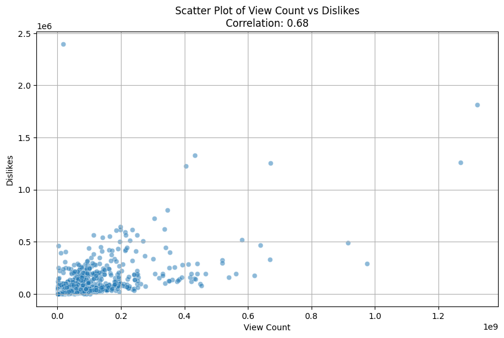

```
Correlation between view_count and dislikes: 0.6844687753905547
```

```python
# Calculate the correlation between 'view_count' and 'dislikes'
correlation = data['view_count'].corr(data['dislikes'])

# Create a scatter plot
plt.figure(figsize=(10, 6))
sns.scatterplot(data=data, x='view_count', y='dislikes', alpha=0.5)
plt.title(f"Scatter Plot of View Count vs Dislikes\nCorrelation: {correlation:.2f}")
plt.xlabel('View Count')
plt.ylabel('Dislikes')
plt.grid(True)
plt.show()

print("Correlation between view_count and dislikes:", correlation)
```

The correlation coefficient between 'view_count' and 'dislikes' is approximately 0.68, which indicates a positive correlation between these two variables. This suggests that there is a moderate positive relationship between the number of views and the number of dislikes a video receives.

The scatter plot will visually represent this relationship. If the points on the scatter plot tend to form an upward-sloping pattern, it further supports the positive correlation, implying that videos with higher view counts tend to have higher numbers of dislikes.

Keep in mind that correlation does not necessarily imply causation. Other factors, such as the video's content, audience engagement, or external events, could contribute to both higher view counts and higher numbers of dislikes.

# 14. Display all the information about the videos that were published in January, and mention the count of videos that were published in January.

```python
# Reference in All data
data
```

|  | video_id | title | channel_id | channel_title | published_at | view_count | likes | dislikes | comment_count | tags | description | comments | published_month |
| --- | --- | --- | --- | --- | --- | --- | --- | --- | --- | --- | --- | --- | --- |
| 0 | --0bCF-iK2E | Jadon Sancho Magical Skills & Goals | UC6UL29enLNe4mqwTfAyeNuw | Bundesliga | 2021-07-01 10:00:00 | 1048888 | 19515 | 226 | 1319 | football soccer ftbol alemn Bundesliga season ... | Enjoy the best skills and goals from Jadon San... | Respect to Dortmund fans,must be sad losing hi... | Jul |
| 1 | --14w5SOEUs | Migos - Avalanche (Official Video) | UCGIelM2Dj3zza3xyV3pL3WQ | MigosVEVO | 2021-06-10 16:00:00 | 15352638 | 359277 | 7479 | 18729 | Migos Avalanche Quality Control Music/Motown R... | Watch the the official video for Migos - "Aval... | Migos just makes me want to live my live to th... | Jun |
| 2 | --40TEbZ9Is | Supporting Actress in a Comedy: 73rd Emmys | UClBKH8yZRcM4AsRjDVEdjMg | Television Academy | 2021-09-20 01:03:32 | 925281 | 11212 | 401 | 831 |  | Hannah Waddingham wins the Emmy for Supporting... | Hannah's energy bursts through any screen. Wel... | Sep |
| 3 | --4tfbSyYDE | JO1'YOUNG (JO1 ver.)' PERFORMANCE VIDEO | UCsmXiDP8S40uBeJYxvyulmA | JO1 | 2021-03-03 10:00:17 | 2641597 | 39131 | 441 | 3745 | PRODUCE101JAPAN JO1 TheSTAR STA... | JO1'YOUNG (JO1 ver.)' PERFORMANCE VIDEO\n\n---... | youngVer>< REN is really PERFECT. It's not ju... | Mar |
| 4 | --DKkzWVh-E | Why Retaining Walls Collapse | UCMOqf8ab-42UUQIdVoKwjlQ | Practical Engineering | 2021-12-07 13:00:00 | 715724 | 32887 | 367 | 1067 | retaining wall New Jersey highway Direct Conne... | One of the most important (and innocuous) part... | Keep up with all my projects here: https://pr... | Dec |
| ... | ... | ... | ... | ... | ... | ... | ... | ... | ... | ... | ... | ... | ... |
| 37417 | zzd4ydafGR0 | Lil Tjay - Calling My Phone (feat. 6LACK) [Off... | UCEB4a5o_6KfjxHwNMnmj54Q | Lil Tjay | 2021-02-12 05:03:49 | 120408275 | 2180780 | 35871 | 81360 | Lil Tjay Steady Calling My Phone Calling My Ph... | Official video for "Calling My Phone" by Lil T... | 'DESTINED 2 WIN' OUT NOW !! https://liltjay.ln... | Feb |
| 37418 | zziBybeSAtw | PELICANS at LAKERS \| FULL GAME HIGHLIGHTS \| Ja... | UCWJ2lWNubArHWmf3FIHbfcQ | NBA | 2021-01-16 05:39:05 | 2841917 | 20759 | 1049 | 2624 | NBA G League Basketball game-0022000187 Lakers... | PELICANS at LAKERS \| FULL GAME HIGHLIGHTS \| Ja... | Montrezl Harrell is going crazy with the rebou... | Jan |
| 37419 | zzk09ESX7e0 | [MV] (MAMAMOO) - Where Are We Now | UCuhAUMLzJxlP1W7mEk0_6lA | MAMAMOO | 2021-06-02 09:00:10 | 13346678 | 720854 | 4426 | 90616 | MAMAMOO WAW WAW MAMAMOO WAW Where Are We Now... | [MV] (MAMAMOO) - Where Are We Now\n\nInstagra... | I honestly do not know why this song hit so ha... | Jun |
| 37420 | zzmQEb0Em5I | FELLIPE ESCUDERO- Master Podcast #12 | UC8NjnNWMsRqq11NYvHAQb1g | Master Podcast | 2020-10-20 20:59:30 | 252057 | 19198 | 1234 | 1471 | master masterpodcast lord lord vinheteiro z z ... | DOCTOR HAIR\nhttps://www.thedoctorhair.com/?fb... | Foi um prazer passar esta tarde com vocs debat... | Oct |
| 37421 | zzxPZwaA-8w | Gareth Bale brace secures dramatic comeback on... | UCEg25rdRZXg32iwai6N6l0w | Tottenham Hotspur | 2021-05-23 21:00:31 | 2252090 | 34063 | 868 | 2004 | Spurs Tottenham Hotspur Tottenham Leicester ... | Two minute highlights from Tottenham Hotspur's... | Thank you Kane for everything you have given t... | May |

37422 rows × 13 columns

```python
# Filter videos published in January
videos_january = data[data['published_at'].dt.month == 1]

# Display information about videos published in January
videos_january
```

|  | video_id | title | channel_id | channel_title | published_at | view_count | likes | dislikes | comment_count | tags | description | comments | published_month |
| --- | --- | --- | --- | --- | --- | --- | --- | --- | --- | --- | --- | --- | --- |
| 27 | -2Gwm7QfBnE | Q&A With Naisha | UCYwNMbogQFzMccPSuy-pPWg | MianTwins | 2021-01-21 00:05:47 | 872372 | 38626 | 239 | 621 |  | Hey Guys!!! this has been the most requested v... | I feel like Nate and Aishas personality match ... | Jan |
| 48 | -4sfXSHSxzA | SURPRISING BRENT WITH HIS TIKTOK CRUSH!! | UCPpATKqmMV-CNRNWYaDUwiA | Alexa Rivera | 2021-01-16 21:40:04 | 6504784 | 262477 | 5779 | 7907 |  | He had no idea! Thank you guys so much for wat... | Thank you guys for watching and don't forget t... | Jan |
| 95 | -AJD1Fc5rpQ | WE ARE HAVING A BABY! \| finding out i'm pregna... | UCVsTboAhpnuL6j-tDePvNwQ | Tess Christine | 2021-01-03 21:53:48 | 533084 | 38965 | 119 | 1650 |  | I am so happy to tell you that I am pregnant!!... | Okay I needed a moment to collect my thoughts ... | Jan |
| 103 | -AuJiwjsmWk | Do Ugly Foods Taste Worse? Taste Test | UCzpCc5n9hqiVC7HhPwcIKEg | Good Mythical MORE | 2021-01-19 11:00:01 | 1057077 | 22526 | 531 | 773 | gmm good mythical morning rhettandlink rhett a... | Today, we're doing a blind taste test to deter... | "there's nothing wrong with it being bent"\nI ... | Jan |
| 182 | -JhqO2KWr5U | Schlatt gets fit | UCWZp4y1jqBuvLtiyxSs_ZBw | Big guy | 2021-01-24 22:50:57 | 1724965 | 119431 | 325 | 1578 | jschlatt big guy jschlatt highlights schlatt j... | #jschlatt #schlatt #bigguy #short | Schlatt is single handedly wiping out all the ... | Jan |
| ... | ... | ... | ... | ... | ... | ... | ... | ... | ... | ... | ... | ... | ... |
| 37300 | zmzFL5bG-jc | DEVINE MON PERSONNAGE AVANT AKINATOR ! (c'est ... | UCIlr3byh6wmXgcPx_Tm9Ocw | Piwerre | 2021-01-16 16:12:19 | 670357 | 54462 | 832 | 1249 | Piwerre frere de michou crouton among us devin... | Discord Piwerre : https://discord.gg/QBduPgAA... | Mdr michou quand c'est pas ses tournage il fou... | Jan |
| 37329 | zpzjex7qwrA | Lampard Sacked Within Days Rorys Misery \| Chel... | UCkD-ZOixI0a9FjIExDsHsbg | The Kick Off | 2021-01-03 20:13:49 | 428646 | 12060 | 296 | 1505 | Premier league Chelsea chelsea 1-3 Man City Ch... | The Kick Off watched Manchester City destroy C... | True Its like a fighter who Geordie But I thou... | Jan |
| 37345 | zqyv-B6mnBM | Lil Wayne - Ain't Got Time (Audio) | UCO9zJy7HWrIS3ojB4Lr7Yqw | Lil Wayne | 2021-01-21 05:00:10 | 2238244 | 58925 | 2365 | 5539 | lil wayne weezy weezy wednesday wayne carter y... | Official audio for Lil Wayne "Ain't Got Time",... | RIP Juice Wrld, wrote that on two cups, pour o... | Jan |
| 37383 | zwfu1-24T7Q | PRADA Cup Day 1 \| Full Race Replay \| PRADA Cup... | UCo15ZYO_XDRU9LI30OPtxAg | America's Cup | 2021-01-15 04:07:55 | 317382 | 2008 | 83 | 192 | America's Cup Americas Cup AC36 AC75 Presented... | The opening day of the PRADA Cup in Auckland, ... | Incredible how these boats evolve in a short t... | Jan |
| 37418 | zziBybeSAtw | PELICANS at LAKERS \| FULL GAME HIGHLIGHTS \| Ja... | UCWJ2lWNubArHWmf3FIHbfcQ | NBA | 2021-01-16 05:39:05 | 2841917 | 20759 | 1049 | 2624 | NBA G League Basketball game-0022000187 Lakers... | PELICANS at LAKERS \| FULL GAME HIGHLIGHTS \| Ja... | Montrezl Harrell is going crazy with the rebou... | Jan |

2108 rows × 13 columns

```python
print(videos_january)
```

```
          video_id                                              title  \
27     -2Gwm7QfBnE                                    Q&A With Naisha
48     -4sfXSHSxzA           SURPRISING BRENT WITH HIS TIKTOK CRUSH!!
95     -AJD1Fc5rpQ  WE ARE HAVING A BABY! | finding out i'm pregna...
103    -AuJiwjsmWk              Do Ugly Foods Taste Worse? Taste Test
182    -JhqO2KWr5U                                   Schlatt gets fit
...            ...                                                ...
37300  zmzFL5bG-jc  DEVINE MON PERSONNAGE AVANT AKINATOR ! (c'est ...
37329  zpzjex7qwrA  Lampard Sacked Within Days Rorys Misery | Chel...
37345  zqyv-B6mnBM                 Lil Wayne - Ain't Got Time (Audio)
37383  zwfu1-24T7Q  PRADA Cup Day 1 | Full Race Replay | PRADA Cup...
37418  zziBybeSAtw  PELICANS at LAKERS | FULL GAME HIGHLIGHTS | Ja...

                     channel_id       channel_title        published_at  \
27     UCYwNMbogQFzMccPSuy-pPWg           MianTwins 2021-01-21 00:05:47
```

[output cut: 64 more lines]

```python
# Convert 'published_at' column to datetime if not done already
data['published_at'] = pd.to_datetime(data['published_at'])

# Count the number of videos published in January
count_january_videos = videos_january.shape[0]
print("Count of videos published in January:", count_january_videos)
```

```
Count of videos published in January: 2108
```

This shows information about videos that were published in January, and you can see various details like video title, channel, view count, likes, dislikes, comment count, tags, description, comments, and the month of publication.

There are a total of 2,108 videos that were published in January.